# Random Forest - Data Science Capstone

Author

Sierra Landacre, Pamela Mishaw, Pallak Singh, and Tim Leschke II

Published

July 6, 2024

## Introduction

### Related work

The organization of this section is inspired by Clinton Sheppard (Sheppard 2017).

#### Decision Tree Algorithms

- Decision tree algorithms that perform classification with ONE TEST to determine the partition for NON-CONTINUOUS/NON-NUMERICAL data.
- Decision tree algorithms that perform classification with MULTIPLE TESTS to determine the partition for NON-CONTINUOUS/NON-NUMERICAL data.
- Decision tree algorithms that handle NUMERICAL (but non-continuous) data.
- Decision tree algorithms that use pruning to improve the accuracy of predictions.

#### Random Forest

- Better at handling noisy data than a decision tree.
- Better compute time by only working with a subset (sample) of the data

#### Random Forest & Regression Analysis

- Decision tree/Random Forests algorithms that use REGRESSION ANALYSIS to predict continuous outcomes (ranges of numeric values, like age 60-75 years).

#### Random Forest & Boosting

- Decision tree/Random Forest algorithms that use BOOSTING to increase prediction accuracy.

## Methods

The common non-parametric regression model is $Y_i = m(X_i) + \varepsilon_i$, where $Y_i$ can be defined as the sum of the regression function value $m(x)$ for $X_i$. Here $m(x)$ is unknown and $\varepsilon_i$ some errors. With the help of this definition, we can create the estimation for local averaging i.e. $m(x)$ can be estimated with the product of $Y_i$ average and $X_i$ is near to $x$. In other words, this means that we are discovering the line through the data points with the help of surrounding data points. The estimation formula is printed below (R Core Team 2019):

$$M_n(x) = \sum_{i=1}^{n} W_n (X_i) Y_i \tag{1}$$
$W_n(x)$ is the sum of weights that belongs to all real numbers. Weights are positive numbers and small if $X_i$ is far from $x$.

Another equation:

$$y_i = \beta_0 + \beta_1 X_1 +\varepsilon_i$$

## Analysis and Results

### Data and Visualization

```r
# loading packages
library(tidyverse)
library(knitr)
#library(ggthemes)
library(ggrepel)
library(dslabs)
```

```r
# Load Data
kable(head(murders))
```

| state | abb | region | population | total |
| --- | --- | --- | --- | --- |
| Alabama | AL | South | 4779736 | 135 |
| Alaska | AK | West | 710231 | 19 |
| Arizona | AZ | West | 6392017 | 232 |
| Arkansas | AR | South | 2915918 | 93 |
| California | CA | West | 37253956 | 1257 |
| Colorado | CO | West | 5029196 | 65 |

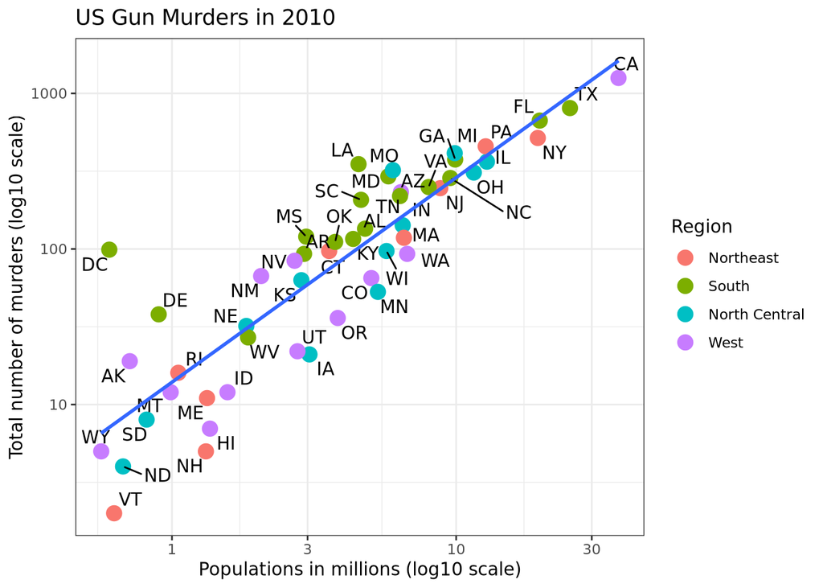

```r
ggplot1 = murders %>% ggplot(mapping = aes(x=population/10^6, y=total))

  ggplot1 + geom_point(aes(col=region), size = 4) +
  geom_text_repel(aes(label=abb)) +
  scale_x_log10() +
  scale_y_log10() +
  geom_smooth(formula = "y~x", method=lm,se = F)+
  xlab("Populations in millions (log10 scale)") +
  ylab("Total number of murders (log10 scale)") +
  ggtitle("US Gun Murders in 2010") +
  scale_color_discrete(name = "Region")+
      theme_bw()
```

### Random Forest Created by Tim

```r
wine <- read.csv(url("https://archive.ics.uci.edu/ml/machine-learning-databases/wine-quality/winequality-red.csv"), header = TRUE, sep = ";") # This command is used to load the dataset

head(wine) # Display the head and dimensions of wine dataset
```

```
  fixed.acidity volatile.acidity citric.acid residual.sugar chlorides
1           7.4             0.70        0.00            1.9     0.076
2           7.8             0.88        0.00            2.6     0.098
3           7.8             0.76        0.04            2.3     0.092
4          11.2             0.28        0.56            1.9     0.075
5           7.4             0.70        0.00            1.9     0.076
6           7.4             0.66        0.00            1.8     0.075
  free.sulfur.dioxide total.sulfur.dioxide density   pH sulphates alcohol
1                  11                   34  0.9978 3.51      0.56     9.4
2                  25                   67  0.9968 3.20      0.68     9.8
3                  15                   54  0.9970 3.26      0.65     9.8
4                  17                   60  0.9980 3.16      0.58     9.8
5                  11                   34  0.9978 3.51      0.56     9.4
6                  13                   40  0.9978 3.51      0.56     9.4
  quality
1       5
2       5
3       5
4       6
5       5
6       5
```

```r
dim(wine)
```

```
[1] 1599   12
```

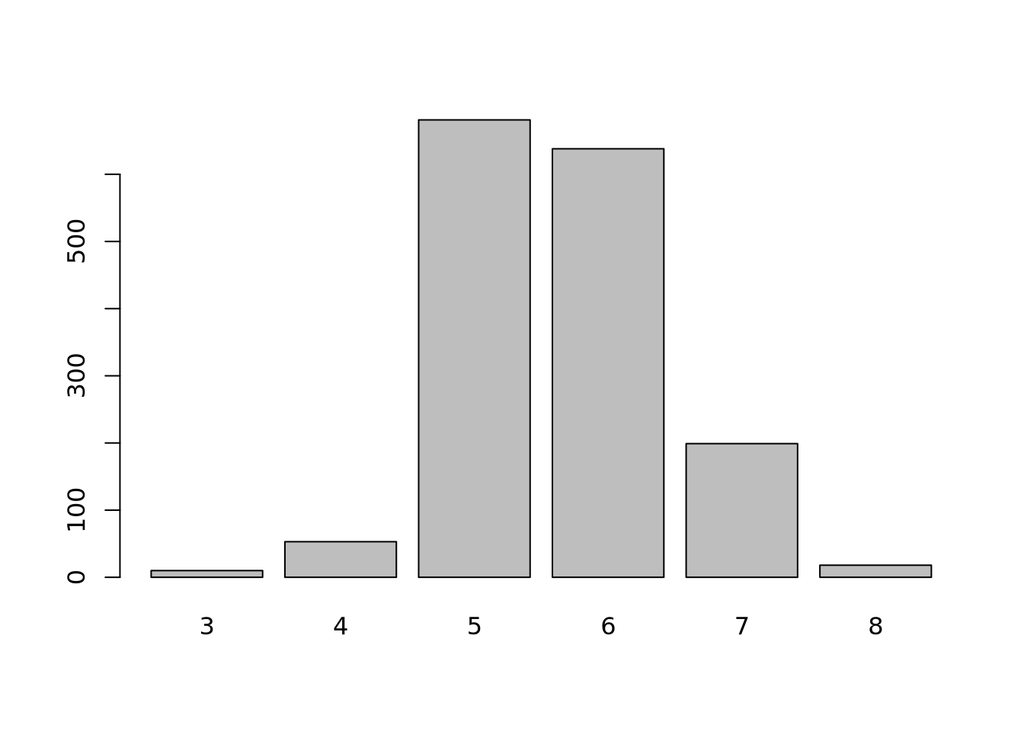

```r
barplot(table(wine$quality)) # Barplot to see the quality of wines. The output looks like below
```

```r
# Now, we have to convert the quality values into factors

wine$taste <- ifelse(wine$quality < 5, "bad", "good")

wine$taste[wine$quality == 5] <- "normal"

wine$taste[wine$quality == 6] <- "normal"

wine$taste <- as.factor(wine$taste)

str(wine$taste)
```

```
 Factor w/ 3 levels "bad","good","normal": 3 3 3 3 3 3 3 2 2 3 ...
```

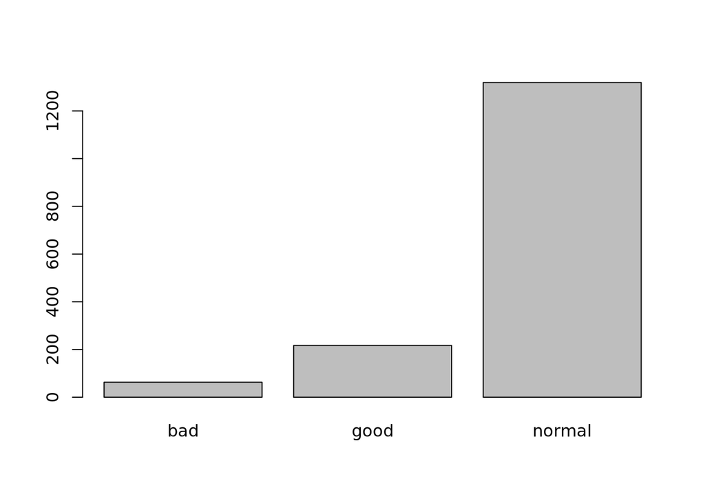

```r
barplot(table(wine$taste)) # Barplot to view the taste of wines. The output is shown below.
```

```r
table(wine$taste)
```

```
   bad   good normal
    63    217   1319
```

```r
# Next, we need to split the data into training and testing. 80% for training, 20% for testing.


set.seed(123)

samp <- sample(nrow(wine), 0.8 * nrow(wine))

train <- wine[samp, ]

test <- wine[-samp, ]
```

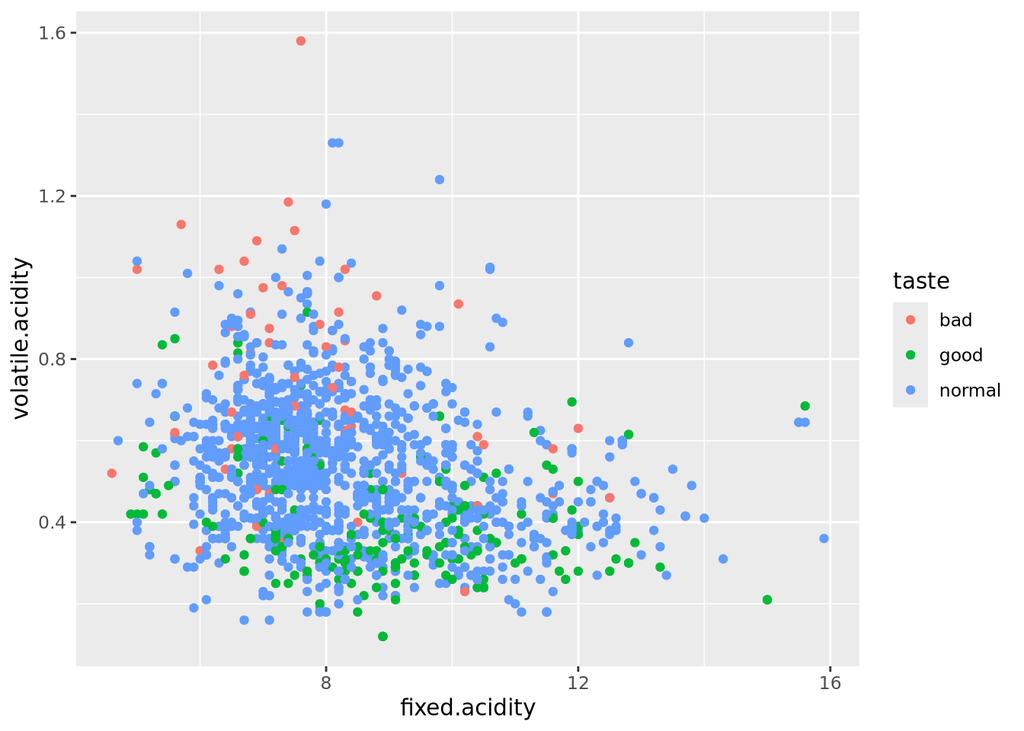

```r
# Moving onto the Data visualization

library(ggplot2)


ggplot(wine,aes(fixed.acidity,volatile.acidity))+ geom_point(aes(color=taste))# This command is used to display a scatter plot. The output looks like below
```

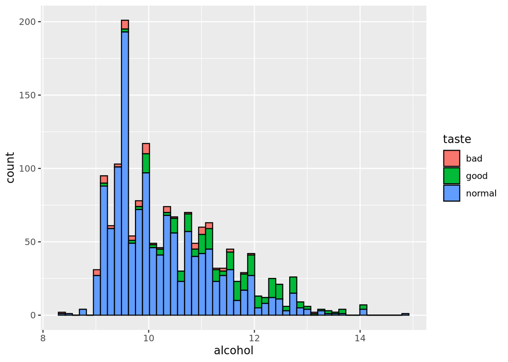

```r
ggplot(wine,aes(alcohol)) + geom_histogram(aes(fill=taste),color='black',bins=50) # This command is used to display a stacked bar chart. The output looks like below
```

```r
dim(train)
```

```
[1] 1279   13
```

```r
dim(test)  # Checks the dimensions of training and testing dataset
```

```
[1] 320  13
```

```r
install.packages('randomForest', repo="https://cran.r-project.org/package=randomForest")

library(randomForest)           # Install the random forest library


# Now that we have installed the randomforest library, let’s build the random forest model


model <- randomForest(taste ~ . - quality, data = train, ntree = 1000, mtry = 5)

model
```

```
Call:
 randomForest(formula = taste ~ . - quality, data = train, ntree = 1000,      mtry = 5)
               Type of random forest: classification
                     Number of trees: 1000
No. of variables tried at each split: 5

        OOB estimate of  error rate: 14.23%
Confusion matrix:
       bad good normal class.error
bad      0    1     51  1.00000000
good     0   99     89  0.47340426
normal   1   40    998  0.03946102
```

```r
model$confusion
```

```
       bad good normal class.error
bad      0    1     51  1.00000000
good     0   99     89  0.47340426
normal   1   40    998  0.03946102
```

```r
# The next step is to validate our model using the test data

prediction <- predict(model, newdata = test)

table(prediction, test$taste)
```

```
prediction bad good normal
    bad      1    0      2
    good     0   18      8
    normal  10   11    270
```

```r
prediction
```

[output not shown]

```r
# Now, let’s display the predicted vs. the actual values


results<-cbind(prediction,test$taste)

results
```

```
     prediction
3             3 3
7             3 3
15            3 3
22            3 3
23            3 3
27            3 3
43            3 3
47            3 3
50            3 3
53            3 3
57            3 3
59            3 3
62            3 3
65            1 3
```

[output cut: 306 more lines]

```r
colnames(results)<-c('pred','real')

results<-as.data.frame(results)

#View(results)
library(DT)
datatable(results)
```

|  | pred | real |
| --- | --- | --- |
| 3 | 3 | 3 |
| 7 | 3 | 3 |
| 15 | 3 | 3 |
| 22 | 3 | 3 |
| 23 | 3 | 3 |
| 27 | 3 | 3 |
| 43 | 3 | 3 |
| 47 | 3 | 3 |
| 50 | 3 | 3 |
| 53 | 3 | 3 |

[output cut: 310 more lines]

```r
# Finally, let’s calculate the accuracy of the model

sum(prediction==test$taste) / nrow(test) # The output is as shown below
```

```
[1] 0.903125
```

Tim updated the references.bib file with the following references; (Quinlan 1986), (Rachmawanto et al. 2021), (Yuan et al. 2015), (boryczka and Kozak 2011), and (Breiman 2001)…

## References

boryczka, urszula, and Jan Kozak. 2011. “New Insights of Cooperation Among Ants in Ant Colony Decisioon Trees.” *Third World Congress on Nature & Biologically Inspired Computing*, 255–60.

Breiman, Leo. 2001. “Random Forests.” *Machine Learning* 45: 5–32.

Bro, Rasmus, and Age K Smilde. 2014. “Principal Component Analysis.” *Analytical Methods* 6 (9): 2812–31.

Daffertshofer, Andreas, Claudine JC Lamoth, Onno G Meijer, and Peter J Beek. 2004. “PCA in Studying Coordination and Variability: A Tutorial.” *Clinical Biomechanics* 19 (4): 415–28.

Efromovich, S. 2008. *Nonparametric Curve Estimation: Methods, Theory, and Applications*. Springer Series in Statistics. Springer New York. https://books.google.com/books?id=mdoLBwAAQBAJ.

Quinlan, J. R. 1986. “Induction of Decision Trees.” *Machine Learning* 1: 81–106.

R Core Team. 2019. *R: A Language and Environment for Statistical Computing*. Vienna, Austria: R Foundation for Statistical Computing. https://www.R-project.org.

Rachmawanto, Eko Hari, De Rosal Ignatious Moses Setiadi, Nova Rijati, Ajib Susanto, Ibnu Utomo Wahyu Mulyono, and Hidayah Rahmalan. 2021. “Attribute Selection Analysis for the Random Forest Classification in Unbalanced Diabetes Dataset.” *2021 International Seminar on Application for Technology of Informatoon and Communication (iSemantic)*, 82–86.

Sheppard, Clinton. 2017. *Tree-Based Machine Learning Algorithms; Decision Trees, Random Forests, and Boosting*. CreateSpace Independent Publishing Platform.

Wang, Ming. 2014. “Generalized Estimating Equations in Longitudinal Data Analysis: A Review and Recent Developments.” *Advances in Statistics* 2014.

Yuan, Fangfang, Fusheng Lian, Xingjian Xu, and Zhaohua Ji. 2015. “Decision Tree Algorithm OPtimization Research Based on MapReduce.” *2015 6th IEEE International Conference on Software Engineering and Service Science (ICSESS)*, 1010–13.